# Relatório de Regressão Linear

### **Título:** Análise financeira do Google

### **Autor:** Glauco Lauria Marques Filho

# Resumo

#### Este relatório descreve uma análise de regressão linear realizada para prever o Preço de fechamento das ações do Google com base em indicadores financeiros. O estudo inclui a coleta e análise de dados, a criação do modelo de regressão, bem como a avaliação de sua precisão.

# Sumário

- Início
- Resumo
- Sumário
- Introdução (O que)
- Motivação (Por que)
- Metodologia (Como)
  1. Coleta de Dados
  2. Análise Exploratória de Dados (EDA)
     - 2.1. Valores Ausentes
     - 2.2. Outliers
     - 2.3. Estatísticas Descritivas
     - 2.4. Distribuição das Variáveis
  3. Modelagem de Regressão Linear
     - 3.1. Modelo Linear Inicial
     - 3.2. Modelo Linear Corrigido
  4. Avaliação do Modelo
     - 4.1. Testes de Heterocedasticidade
     - 4.2. Testes de Multicolinearidade
     - 4.3. Testes de Autocorrelação dos Resíduos
     - 4.4. Erro Quadrático e Absoluto
     - 4.5. Coeficiente de Determinação
- Resultados
- Modelo de Regressão Linear
- Discussão
- Conclusão

# Introdução (O que)

#### A análise de regressão linear é uma técnica estatística que visa entender as relações entre uma variável dependente e uma ou mais variáveis independentes. Neste estudo, o objetivo é prever o Preço de fechamento das ações do Google com base em indicadores financeiros diversos como EBITDA, Cash Flow e outros.

# Motivação (Por que)

A análise de regressão linear é realizada para compreender as relações entre a variável dependente, Adj. Close, e as variáveis independentes:

EBITDA  
Total Debt  
Free Cash Flow  
Gross Profit Margin  
Operating Margin  
Net Profit Margin  
Return on Equity  
Return on Assets  
Free Cash Flow to Net Income  
Current Ratio  
Liabilities to Equity Ratio  
Debt Ratio  
Earnings Per Share, Basic  
Sales Per Share  
Equity Per Share

Isso permite prever com precisão a Adj. Close e, assim, ajudar pessoas interessadas em ações a prever o preço de fechamento das ações baseados no indicadores atuais do Google.

# Metodologia (Como)

```python
# Importando as bibliotecas necessárias
import numpy as np
import statsmodels.api as sm
import matplotlib.pyplot as plt
import pandas as pd
import seaborn as sns
from statsmodels.stats.diagnostic import het_breuschpagan
from statsmodels.stats.outliers_influence import variance_inflation_factor
from statsmodels.stats.stattools import durbin_watson
```

## 1. Coleta de Dados

##### Os dados foram coletados pelo professor Elton, eles são referentes a indicadores de desempenho financeiro da empresa Google, sendo 4 relatórios por ano, de 2014 até 2023, esse último apenas com 3 relatórios.

```python
df = pd.read_parquet("fund_goog.parquet")
df.reset_index(inplace=True)
df["Date"] = pd.to_datetime(df["Date"])
df = df.sort_values(by="Date", ascending=True)
df
```

|  | Date | Adj. Close | EBITDA | Total Debt | Free Cash Flow | Gross Profit Margin | Operating Margin | Net Profit Margin | Return on Equity | Return on Assets | Free Cash Flow to Net Income | Current Ratio | Liabilities to Equity Ratio | Debt Ratio | Earnings Per Share, Basic | Sales Per Share | Equity Per Share |
| --- | --- | --- | --- | --- | --- | --- | --- | --- | --- | --- | --- | --- | --- | --- | --- | --- | --- |
| 0 | 2014-03-27 | 27.92 | 1.818400e+10 | 5.245000e+09 | 1.372100e+10 | 0.60387 | 0.27744 | 0.22934 | 0.14584 | 0.11479 | 1.07759 | 4.58172 | 0.27043 | 0.04729 | 0.95637 | 4.17002 | 6.55776 |
| 1 | 2014-04-24 | 26.26 | 1.878300e+10 | 6.243000e+09 | 1.432200e+10 | 0.60650 | 0.27195 | 0.22141 | 0.13999 | 0.11018 | 1.11551 | 4.62901 | 0.27058 | 0.05358 | 0.96012 | 4.33645 | 6.85832 |
| 2 | 2014-07-25 | 29.45 | 1.964200e+10 | 5.241000e+09 | 1.460300e+10 | 0.60982 | 0.27226 | 0.21306 | 0.13537 | 0.10659 | 1.12660 | 4.55665 | 0.27007 | 0.04310 | 0.96566 | 4.53222 | 7.13320 |
| 3 | 2014-10-23 | 27.20 | 1.979600e+10 | 5.239000e+09 | 1.543500e+10 | 0.60659 | 0.25982 | 0.20016 | 0.12884 | 0.10122 | 1.21239 | 4.47070 | 0.27289 | 0.04165 | 0.94497 | 4.72116 | 7.33466 |
| 4 | 2015-01-29 | 25.53 | 2.001900e+10 | 5.237000e+09 | 1.329000e+10 | 0.61075 | 0.24994 | 0.21541 | 0.13689 | 0.11005 | 0.93480 | 4.68776 | 0.24386 | 0.04054 | 1.05165 | 4.88220 | 7.68269 |
| 5 | 2015-04-29 | 27.45 | 2.047300e+10 | 5.235000e+09 | 1.489700e+10 | 0.61547 | 0.24806 | 0.21050 | 0.13168 | 0.10705 | 1.04321 | 5.60219 | 0.23008 | 0.03924 | 1.05307 | 5.00275 | 7.99744 |
| 6 | 2015-07-23 | 32.21 | 2.123800e+10 | 5.233000e+09 | 1.596000e+10 | 0.61852 | 0.24989 | 0.20597 | 0.12827 | 0.10329 | 1.11313 | 4.84760 | 0.24175 | 0.03770 | 1.05404 | 5.11738 | 8.21762 |
| 7 | 2015-10-29 | 35.85 | 2.236800e+10 | 5.231000e+09 | 1.607600e+10 | 0.62520 | 0.25611 | 0.21708 | 0.13401 | 0.10797 | 1.03197 | 4.65357 | 0.24122 | 0.03626 | 1.14128 | 5.25754 | 8.51611 |
| 8 | 2016-02-04 | 35.40 | 2.349200e+10 | 5.220000e+09 | 1.647100e+10 | 0.62442 | 0.25817 | 0.21104 | 0.13152 | 0.10732 | 1.04076 | 4.66670 | 0.22546 | 0.03540 | 1.15581 | 5.47664 | 8.78808 |
| 9 | 2016-05-03 | 34.62 | 2.460400e+10 | 5.208000e+09 | 1.706400e+10 | 0.62230 | 0.25972 | 0.21180 | 0.13367 | 0.11031 | 1.03305 | 5.14335 | 0.21185 | 0.03478 | 1.20345 | 5.68196 | 9.00285 |
| 10 | 2016-08-04 | 38.58 | 2.600700e+10 | 4.203000e+09 | 1.938700e+10 | 0.62081 | 0.26171 | 0.21998 | 0.14065 | 0.11657 | 1.07789 | 5.43440 | 0.20655 | 0.02724 | 1.30916 | 5.95121 | 9.30805 |
| 11 | 2016-11-03 | 38.11 | 2.741300e+10 | 3.938000e+09 | 2.265600e+10 | 0.61812 | 0.26254 | 0.22292 | 0.14219 | 0.11921 | 1.18817 | 6.88026 | 0.19272 | 0.02462 | 1.38735 | 6.22351 | 9.75708 |
| 12 | 2017-02-03 | 40.07 | 2.898300e+10 | 3.935000e+09 | 2.698300e+10 | 0.61075 | 0.26272 | 0.21577 | 0.14009 | 0.11629 | 1.38531 | 6.29076 | 0.20470 | 0.02349 | 1.41601 | 6.56258 | 10.10762 |
| 13 | 2017-05-02 | 45.82 | 3.034100e+10 | 3.937000e+09 | 2.886600e+10 | 0.60655 | 0.26320 | 0.21840 | 0.14279 | 0.11980 | 1.39469 | 7.13123 | 0.19184 | 0.02279 | 1.50242 | 6.87912 | 10.52204 |
| 14 | 2017-07-25 | 47.53 | 3.139400e+10 | 3.955000e+09 | 2.786000e+10 | 0.60183 | 0.26031 | 0.19485 | 0.13045 | 0.10830 | 1.44024 | 6.01477 | 0.20457 | 0.02214 | 1.40129 | 7.19152 | 10.74190 |
| 15 | 2017-10-27 | 50.96 | 3.359300e+10 | 3.964000e+09 | 2.724500e+10 | 0.59867 | 0.26633 | 0.20092 | 0.13377 | 0.11088 | 1.29645 | 5.76741 | 0.20647 | 0.02091 | 1.51908 | 7.56076 | 11.35603 |
| 16 | 2018-02-06 | 54.03 | 3.498500e+10 | 3.969000e+09 | 4.567700e+10 | 0.58881 | 0.26054 | 0.11422 | 0.08303 | 0.06418 | 3.60741 | 5.14031 | 0.29372 | 0.02012 | 0.91369 | 7.99934 | 11.00460 |
| 17 | 2018-04-24 | 51.00 | 3.655400e+10 | 5.302000e+09 | 4.333700e+10 | 0.57992 | 0.25541 | 0.14189 | 0.10345 | 0.08040 | 2.60486 | 4.87363 | 0.28671 | 0.02562 | 1.19915 | 8.45113 | 11.59182 |
| 18 | 2018-07-24 | 62.40 | 3.800200e+10 | 3.981000e+09 | 4.550800e+10 | 0.57413 | 0.24986 | 0.13162 | 0.10067 | 0.07707 | 2.79053 | 4.15199 | 0.30623 | 0.01881 | 1.17418 | 8.92066 | 11.66400 |
| 19 | 2018-10-26 | 53.57 | 3.910700e+10 | 3.986000e+09 | 4.466000e+10 | 0.56957 | 0.24244 | 0.14452 | 0.11050 | 0.08472 | 2.37958 | 4.14370 | 0.30439 | 0.01799 | 1.35025 | 9.34313 | 12.21903 |
| 20 | 2019-02-06 | 55.76 | 4.139100e+10 | 4.012000e+09 | 2.533700e+10 | 0.56476 | 0.24285 | 0.22465 | 0.17304 | 0.13203 | 0.82434 | 3.91901 | 0.31056 | 0.01723 | 2.21078 | 9.84111 | 12.77642 |
| 21 | 2019-04-30 | 59.42 | 4.268800e+10 | 4.066000e+09 | 2.967400e+10 | 0.56276 | 0.23871 | 0.19711 | 0.15257 | 0.11409 | 1.06009 | 3.95895 | 0.33726 | 0.01657 | 2.01332 | 10.21420 | 13.19621 |
| 22 | 2019-07-26 | 62.52 | 4.475400e+10 | 4.074000e+09 | 2.800100e+10 | 0.55828 | 0.23737 | 0.23428 | 0.18078 | 0.13514 | 0.80592 | 3.98478 | 0.33773 | 0.01585 | 2.49983 | 10.67010 | 13.82820 |
| 23 | 2019-10-29 | 63.13 | 4.621500e+10 | 4.082000e+09 | 3.047800e+10 | 0.55633 | 0.23261 | 0.21037 | 0.16731 | 0.12401 | 0.93433 | 3.78233 | 0.34916 | 0.01552 | 2.34945 | 11.16803 | 14.04262 |
| 24 | 2020-02-04 | 72.35 | 4.678400e+10 | 4.554000e+09 | 2.933700e+10 | 0.55581 | 0.22197 | 0.21218 | 0.17049 | 0.12447 | 0.85424 | 3.37405 | 0.36967 | 0.01651 | 2.47930 | 11.68481 | 14.54253 |
| 25 | 2020-04-29 | 67.07 | 4.693900e+10 | 5.016000e+09 | 2.347200e+10 | 0.55083 | 0.21359 | 0.20712 | 0.16951 | 0.12627 | 0.67991 | 3.65817 | 0.34245 | 0.01835 | 2.49980 | 12.06939 | 14.74732 |
| 26 | 2020-07-31 | 74.15 | 4.469400e+10 | 4.018000e+09 | 2.417800e+10 | 0.54151 | 0.19757 | 0.18993 | 0.15210 | 0.11323 | 0.76673 | 3.41447 | 0.34328 | 0.01443 | 2.29357 | 12.07588 | 15.07918 |
| 27 | 2020-10-30 | 81.05 | 4.728700e+10 | 1.390200e+10 | 2.772000e+10 | 0.53599 | 0.20290 | 0.20799 | 0.16773 | 0.11934 | 0.77619 | 3.41015 | 0.40542 | 0.04646 | 2.61013 | 12.54923 | 15.56156 |
| 28 | 2021-02-03 | 103.50 | 5.412900e+10 | 1.393200e+10 | 4.148800e+10 | 0.53578 | 0.22585 | 0.22062 | 0.18095 | 0.12599 | 1.03027 | 3.06676 | 0.43619 | 0.04359 | 2.95741 | 13.40502 | 16.34392 |
| 29 | 2021-04-28 | 119.00 | 6.221500e+10 | 1.388700e+10 | 5.379400e+10 | 0.54316 | 0.25261 | 0.26115 | 0.22330 | 0.15703 | 1.04733 | 3.10420 | 0.42207 | 0.04246 | 3.79060 | 14.51517 | 16.97501 |
| 30 | 2021-07-28 | 136.38 | 7.474500e+10 | 1.432800e+10 | 6.516300e+10 | 0.55723 | 0.28448 | 0.28570 | 0.26489 | 0.18763 | 1.03550 | 3.15202 | 0.41177 | 0.04272 | 4.66623 | 16.33281 | 17.61562 |
| 31 | 2021-10-27 | 146.43 | 8.435900e+10 | 1.428800e+10 | 7.743000e+10 | 0.56511 | 0.30300 | 0.29521 | 0.28875 | 0.20327 | 1.09646 | 2.97999 | 0.42048 | 0.04113 | 5.26309 | 17.82809 | 18.22734 |
| 32 | 2022-02-02 | 148.04 | 9.026900e+10 | 1.481700e+10 | 7.880700e+10 | 0.56940 | 0.30552 | 0.29512 | 0.30216 | 0.21163 | 1.03648 | 2.92811 | 0.42773 | 0.04124 | 5.71026 | 19.34915 | 18.89838 |
| 33 | 2022-04-27 | 115.02 | 9.499200e+10 | 1.479100e+10 | 8.096100e+10 | 0.56929 | 0.30470 | 0.27573 | 0.29346 | 0.20874 | 1.08616 | 2.87100 | 0.40587 | 0.04142 | 5.62034 | 20.38353 | 14.41461 |
| 34 | 2022-07-27 | 113.60 | 9.605200e+10 | 1.473400e+10 | 7.689500e+10 | 0.56744 | 0.29648 | 0.25892 | 0.28195 | 0.20276 | 1.06775 | 2.80945 | 0.39060 | 0.04148 | 5.45541 | 21.06980 | 14.47007 |
| 35 | 2022-10-26 | 94.82 | 9.300400e+10 | 1.465300e+10 | 6.957500e+10 | 0.56100 | 0.27849 | 0.23746 | 0.26413 | 0.18699 | 1.03859 | 2.51760 | 0.41253 | 0.04090 | 5.10340 | 21.49179 | 19.32161 |
| 36 | 2023-02-03 | 105.22 | 9.012900e+10 | 1.470100e+10 | 6.776500e+10 | 0.55379 | 0.26461 | 0.21204 | 0.23413 | 0.16419 | 1.12994 | 2.37799 | 0.42601 | 0.04025 | 4.49128 | 21.18147 | 19.18251 |
| 37 | 2023-04-26 | 104.45 | 8.691900e+10 | 1.369700e+10 | 6.918400e+10 | 0.55302 | 0.25355 | 0.20585 | 0.22456 | 0.15856 | 1.18088 | 2.35259 | 0.41625 | 0.03707 | 4.42670 | 21.50461 | 19.71253 |
| 38 | 2023-07-26 | 129.66 | 8.888500e+10 | 1.370500e+10 | 7.876600e+10 | 0.55436 | 0.25748 | 0.21052 | 0.22817 | 0.15913 | 1.29224 | 2.17205 | 0.43386 | 0.03578 | 4.64628 | 22.07013 | 20.36341 |

#### Os dados são compostos por:

- Adj. Close: Preço de fechamento das ações do Google;
- EBITDA: Lucro operacional antes de juros, impostos, depreciação e amortização;
- Total Debt: Dívida total;
- Free Cash Flow: Fluxo de caixa livre;
- Gross Profit Margin: Margem de lucro bruto, indicando a rentabilidade;
- Operating Margin: Margem operacional, representando a lucratividade das operações;
- Net Profit Margin: Margem de lucro líquido, indicando a rentabilidade após despesas;
- Return on Equity: Taxa de retorno sobre o patrimônio líquido;
- Return on Assets: Taxa de retorno sobre os ativos;
- Free Cash Flow to Net Income: Relação entre fluxo de caixa livre e lucro líquido;
- Current Ratio: Índice de liquidez corrente;
- Liabilities to Equity Ratio: Proporção das obrigações em relação ao patrimônio;
- Debt Ratio: Proporção da dívida em relação aos ativos;
- Earnings Per Share, Basic: Lucro disponível por ação;
- Sales Per Share: Receita por ação;
- Equity Per Share: Patrimônio líquido por ação.

## 2. Análise Exploratória de Dados (EDA)

#### Foram realizadas análises estatísticas descritivas e visualizações para entender a distribuição das variáveis, identificar valores ausentes e outliers.

### 2.1 Valores Ausentes

##### Não foi encontrado nenhum valor ausente nessa base de dados.

```python
missing_values = df.isnull().sum()
missing_values
```

```
Date                            0
Adj. Close                      0
EBITDA                          0
Total Debt                      0
Free Cash Flow                  0
Gross Profit Margin             0
Operating Margin                0
Net Profit Margin               0
Return on Equity                0
Return on Assets                0
Free Cash Flow to Net Income    0
Current Ratio                   0
Liabilities to Equity Ratio     0
Debt Ratio                      0
Earnings Per Share, Basic       0
Sales Per Share                 0
Equity Per Share                0
dtype: int64
```

### 2.2 Outliers

##### Fazendo uma Análise de Outliers utilizando o método de Intervalo Interquartil (IQR) padrão de 1,5.

```python
Q1 = df.quantile(0.25)
Q3 = df.quantile(0.75)
IQR = Q3 - Q1
outliers = ((df < (Q1 - 1.5 * IQR)) | (df > (Q3 + 1.5 * IQR))).sum()
outliers
```

```
Date                             0
Adj. Close                       0
EBITDA                           0
Total Debt                       0
Free Cash Flow                   0
Gross Profit Margin              0
Operating Margin                 7
Net Profit Margin               10
Return on Equity                 0
Return on Assets                 3
Free Cash Flow to Net Income     7
Current Ratio                    0
Liabilities to Equity Ratio      0
Debt Ratio                       0
Earnings Per Share, Basic        0
Sales Per Share                  0
Equity Per Share                 0
dtype: int64
```

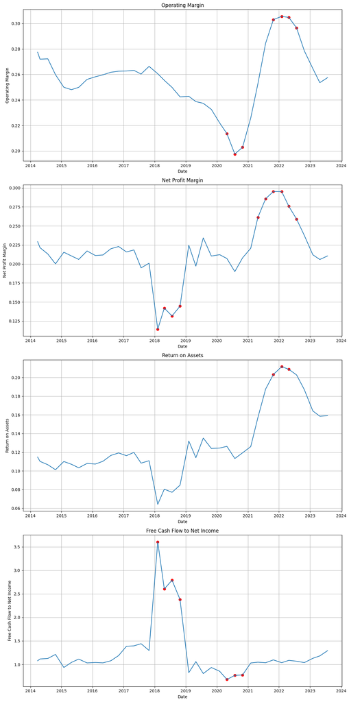

```python
variaveis_com_outliers = [
    "Operating Margin",
    "Net Profit Margin",
    "Return on Assets",
    "Free Cash Flow to Net Income",
]

fig, axs = plt.subplots(
    len(variaveis_com_outliers), 1, figsize=(12, 6 * len(variaveis_com_outliers))
)

for ax, variavel in zip(axs, variaveis_com_outliers):
    sns.lineplot(data=df, x="Date", y=variavel, ax=ax)

    Q1 = df[variavel].quantile(0.25)
    Q3 = df[variavel].quantile(0.75)
    IQR = Q3 - Q1
    outliers = (df[variavel] < (Q1 - 1.5 * IQR)) | (df[variavel] > (Q3 + 1.5 * IQR))

    ax.scatter(df[outliers]["Date"], df[outliers][variavel], color="red")

    ax.set_title(f"{variavel}")
    ax.set_xlabel("Date")
    ax.set_ylabel(variavel)
    ax.grid(True)

plt.tight_layout()
plt.show()
```

```python
estatisticas = pd.DataFrame(
    columns=["Variável", "Mínimo", "Máximo", "Média", "Desvio Padrão"]
)
for variavel in variaveis_com_outliers:
    minimo = df[outliers][variavel].min()
    maximo = df[outliers][variavel].max()
    media = df[outliers][variavel].mean()
    desvio_padrao = df[outliers][variavel].std()
    estatisticas = pd.concat(
        [
            estatisticas,
            pd.DataFrame(
                {
                    "Variável": [variavel],
                    "Mínimo": [minimo],
                    "Máximo": [maximo],
                    "Média": [media],
                    "Desvio Padrão": [desvio_padrao],
                }
            ),
        ],
        ignore_index=True,
    )

estatisticas
```

|  | Variável | Mínimo | Máximo | Média | Desvio Padrão |
| --- | --- | --- | --- | --- | --- |
| 0 | Operating Margin | 0.19757 | 0.26054 | 0.231759 | 0.026335 |
| 1 | Net Profit Margin | 0.11422 | 0.20799 | 0.162470 | 0.038395 |
| 2 | Return on Assets | 0.06418 | 0.12627 | 0.095030 | 0.024127 |
| 3 | Free Cash Flow to Net Income | 0.67991 | 3.60741 | 1.943601 | 1.187271 |

##### Free Cash Flow to Net Income, que representa a relação entre fluxo de caixa livre e lucro líquido.

##### Seus valores variaram de 67,991% até 360,741%, com uma média de 194,3601%. Ao comparar com outras empresas do mesmo segmento vemos que essa variável não indica um outlier, apresentando sim um valor coerente para a natureza do negócio. Segundo o link a seguir, a Microsoft variou de 80% até 200%. [Finbox](https://finbox.com/NASDAQGS:MSFT/explorer/fcf_to_ni/). Logo Free Cash Flow to Net Income foi desconsiderado da presença de Outliers.

### 2.3 Estatísticas Descritivas

#### Uma tabela com as estatísticas descritivas da variáveis pode ser encontrada abaixo:

```python
df.select_dtypes(include=['float64']).describe()
```

|  | Adj. Close | EBITDA | Total Debt | Free Cash Flow | Gross Profit Margin | Operating Margin | Net Profit Margin | Return on Equity | Return on Assets | Free Cash Flow to Net Income | Current Ratio | Liabilities to Equity Ratio | Debt Ratio | Earnings Per Share, Basic | Sales Per Share | Equity Per Share |
| --- | --- | --- | --- | --- | --- | --- | --- | --- | --- | --- | --- | --- | --- | --- | --- | --- |
| count | 39.000000 | 3.900000e+01 | 3.900000e+01 | 3.900000e+01 | 39.000000 | 39.000000 | 39.000000 | 39.000000 | 39.000000 | 39.000000 | 39.000000 | 39.000000 | 39.000000 | 39.000000 | 39.000000 | 39.000000 |
| mean | 67.577692 | 4.644687e+10 | 7.583564e+09 | 3.748828e+10 | 0.581242 | 0.256481 | 0.214944 | 0.171632 | 0.128992 | 1.247115 | 4.192343 | 0.314743 | 0.031852 | 2.429389 | 10.863221 | 12.709229 |
| std | 36.999767 | 2.591525e+10 | 4.567664e+09 | 2.263356e+10 | 0.028747 | 0.024723 | 0.038569 | 0.058617 | 0.037166 | 0.591623 | 1.255188 | 0.083257 | 0.011405 | 1.603210 | 5.874761 | 4.095747 |
| min | 25.530000 | 1.818400e+10 | 3.935000e+09 | 1.329000e+10 | 0.535780 | 0.197570 | 0.114220 | 0.083030 | 0.064180 | 0.679910 | 2.172050 | 0.191840 | 0.014430 | 0.913690 | 4.170020 | 6.557760 |
| 25% | 36.980000 | 2.530550e+10 | 4.042000e+09 | 1.822550e+10 | 0.556780 | 0.245455 | 0.205910 | 0.133720 | 0.108135 | 1.032510 | 3.128110 | 0.241485 | 0.020515 | 1.164995 | 5.816585 | 9.155450 |
| 50% | 55.760000 | 3.910700e+10 | 5.233000e+09 | 2.800100e+10 | 0.569570 | 0.258170 | 0.212180 | 0.145840 | 0.116570 | 1.077590 | 4.143700 | 0.306230 | 0.035780 | 1.519080 | 9.343130 | 12.219030 |
| 75% | 99.160000 | 5.817200e+10 | 1.379600e+10 | 4.973550e+10 | 0.608205 | 0.265470 | 0.223785 | 0.202125 | 0.146085 | 1.200280 | 4.860615 | 0.405645 | 0.041330 | 3.374005 | 13.960095 | 15.320370 |
| max | 148.040000 | 9.605200e+10 | 1.481700e+10 | 8.096100e+10 | 0.625200 | 0.305520 | 0.295210 | 0.302160 | 0.211630 | 3.607410 | 7.131230 | 0.436190 | 0.053580 | 5.710260 | 22.070130 | 20.363410 |

### 2.4 Distribuição das Variáveis

#### A distribuição das variáveis ajuda a entender como os dados estão espalhados e se seguem alguma distribuição, como a normal. Essas visualizações permite identificar se os dados têm uma forma simétrica ou assimétrica, bem como se apresentam múltiplos picos (modas).

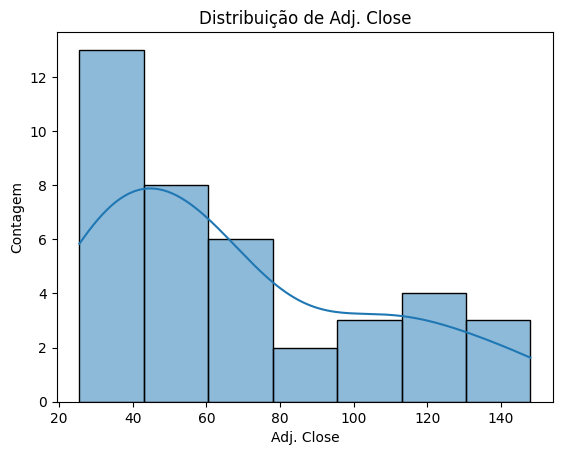

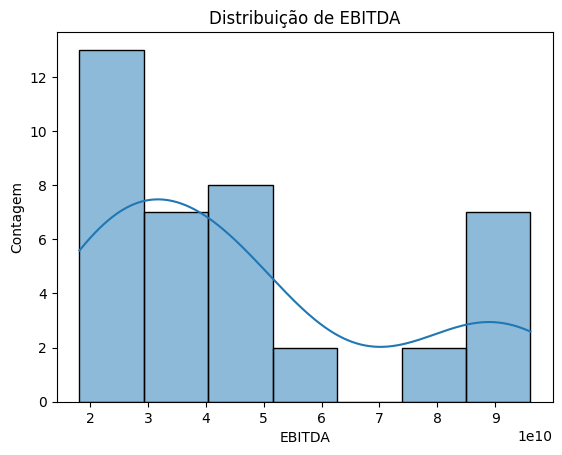

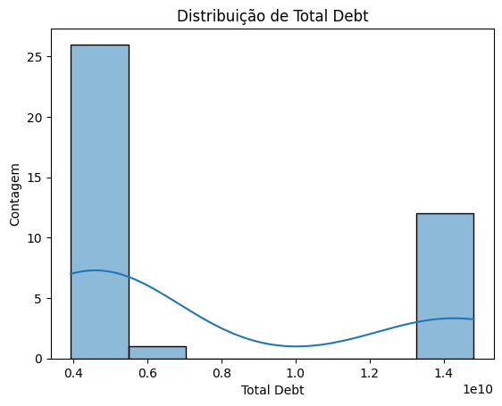

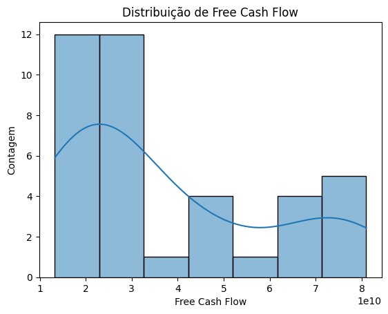

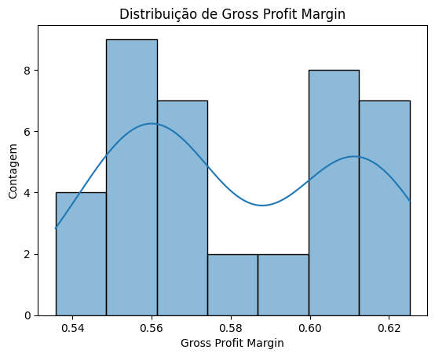

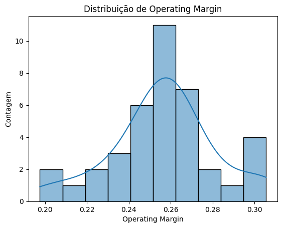

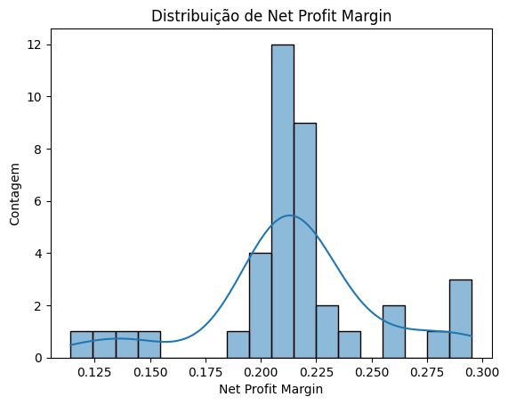

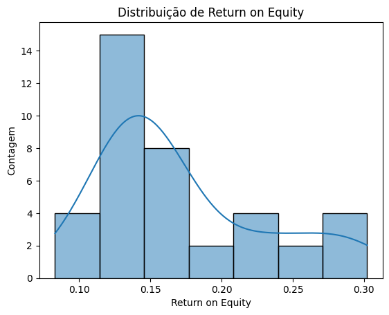

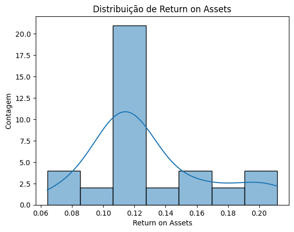

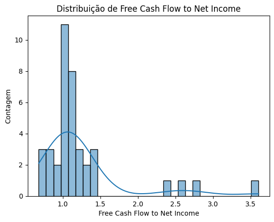

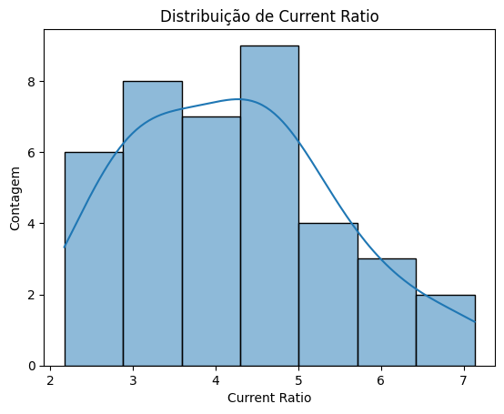

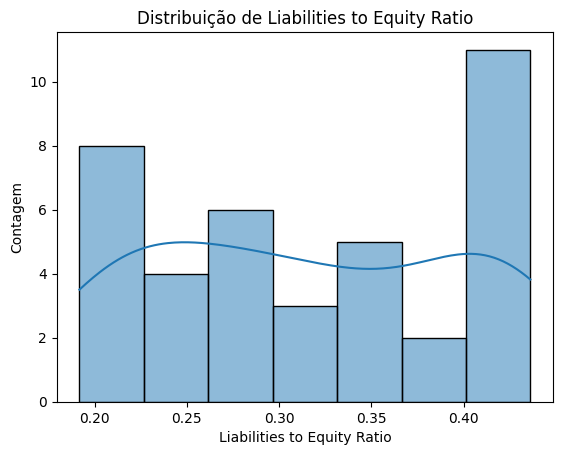

[4 more figures not shown]

```python
num_variaveis = len(df.select_dtypes(include=['float64']).columns)
for i, col in enumerate(df.select_dtypes(include=['float64'])):
    sns.histplot(data=df, x=col, kde=True)
    plt.title(f'Distribuição de {col}')
    plt.xlabel(col)
    plt.ylabel('Contagem')
    plt.show()
```

## 3. Modelagem de Regressão Linear

### 3.1. Modelo Linear Inicial

##### Um modelo de regressão linear foi criado utilizando a biblioteca statsmodels do Python. O processo dessa modelagem pode ser encontrado abaixo:

```python
# Criação de Dataframe de variáveis Independentes
X_df = df.drop(
    "Adj. Close", axis=1
)
X_df = X_df.drop(
    "Date", axis=1
)
# Adicionando uma coluna de 1s (termo linear) ao DataFrame
X_df = sm.add_constant(X_df)

# Criação de Dataframe de variável dependente
Y_df = df["Adj. Close"]
```

```python
# Criando o modelo de regressão linear
modelo = sm.OLS(Y_df, X_df).fit()

# Exibindo um resumo da análise de regressão
print(modelo.summary())
```

```
                            OLS Regression Results
==============================================================================
Dep. Variable:             Adj. Close   R-squared:                       0.987
Model:                            OLS   Adj. R-squared:                  0.980
Method:                 Least Squares   F-statistic:                     130.9
Date:                Tue, 07 Nov 2023   Prob (F-statistic):           3.75e-19
Time:                        19:15:27   Log-Likelihood:                -110.86
No. Observations:                  39   AIC:                             251.7
Df Residuals:                      24   BIC:                             276.7
Df Model:                          14
Covariance Type:            nonrobust
================================================================================================
                                   coef    std err          t      P>|t|      [0.025      0.975]
------------------------------------------------------------------------------------------------
const                          167.9556    193.290      0.869      0.393    -230.976     566.887
EBITDA                       -1.169e-09   1.76e-09     -0.663      0.513   -4.81e-09    2.47e-09
Total Debt                   -4.968e-10   2.96e-09     -0.168      0.868    -6.6e-09     5.6e-09
Free Cash Flow                8.472e-10   4.56e-10      1.857      0.076   -9.43e-11    1.79e-09
Gross Profit Margin           -225.9083    180.565     -1.251      0.223    -598.575     146.759
Operating Margin               143.4393    242.196      0.592      0.559    -356.429     643.308
Net Profit Margin              668.2604    425.135      1.572      0.129    -209.175    1545.696
Return on Equity              -497.7414   3476.967     -0.143      0.887   -7673.850    6678.367
Return on Assets             -1347.4937   4552.638     -0.296      0.770   -1.07e+04    8048.689
Free Cash Flow to Net Income     0.2539      9.559      0.027      0.979     -19.475      19.983
Current Ratio                   -3.4905      3.380     -1.033      0.312     -10.467       3.486
Liabilities to Equity Ratio    -76.8528    406.100     -0.189      0.851    -915.002     761.296
Debt Ratio                      91.3660    829.657      0.110      0.913   -1620.963    1803.695
Earnings Per Share, Basic       64.7677     29.450      2.199      0.038       3.986     125.549
Sales Per Share                 -1.5295      7.124     -0.215      0.832     -16.233      13.174
Equity Per Share                 2.4322      2.066      1.177      0.251      -1.831       6.695
==============================================================================
Omnibus:                        5.654   Durbin-Watson:                   2.833
Prob(Omnibus):                  0.059   Jarque-Bera (JB):                4.247
Skew:                          -0.690   Prob(JB):                        0.120
Kurtosis:                       3.841   Cond. No.                     4.68e+14
==============================================================================

Notes:
[1] Standard Errors assume that the covariance matrix of the errors is correctly specified.
[2] The condition number is large, 4.68e+14. This might indicate that there are
strong multicollinearity or other numerical problems.
```

##### Com o modelo gerado foi plotado o gráfico de Dispersão dos Resíduos a fim de se verificar comportamentos de heterocedasticidade.

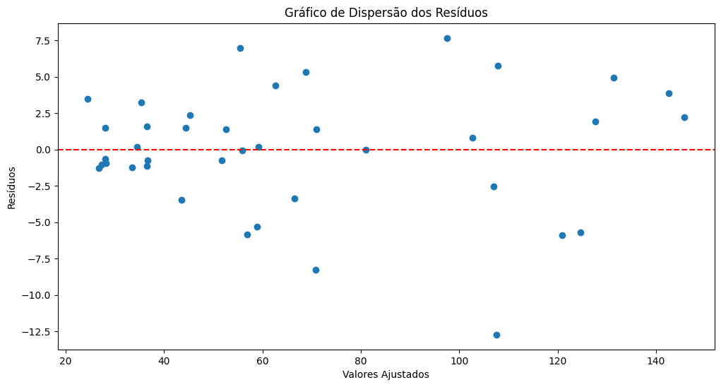

```python
plt.figure(figsize=(12, 6))
plt.scatter(modelo.fittedvalues, modelo.resid)
plt.axhline(y=0, color="r", linestyle="--")
plt.xlabel("Valores Ajustados")
plt.ylabel("Resíduos")
plt.title("Gráfico de Dispersão dos Resíduos")
```

#### Visualmente nada indica uma heterocedasticidade. Faremos o teste de Breusch-Pagan a fim de se confirmar numericamente.

```python
bp_test = het_breuschpagan(modelo.resid, X_df)
print(f"p-valor: {bp_test[1]}")
```

```
p-valor: 0.20115565736996738
```

Como o p-valor é de 0,20 (acima de 0,05), não há evidência estatística para rejeitar a hipótese nula. Portanto, com base no teste Breusch-Pagan, não há indicação de heterocedasticidade nos resíduos do modelo. Isso significa que a variância dos erros é considerada constante e a suposição de homocedasticidade é atendida.

#### Teste de Variance Inflation Factor (VIF) para verificar a presença de multicolinearidade.

```python
vif = pd.DataFrame()
vif["Variável"] = X_df.columns
vif["VIF"] = [variance_inflation_factor(X_df.values, i) for i in range(X_df.shape[1])]
print(f"Teste VIF (Multicolinearidade):\n{vif}")
```

```
Teste VIF (Multicolinearidade):
                        Variável           VIF
0                          const  52012.934091
1                         EBITDA   2828.167355
2                     Total Debt    247.319019
3                 Free Cash Flow    144.604620
4            Gross Profit Margin     36.547881
5               Operating Margin     48.636792
6              Net Profit Margin    364.713862
7               Return on Equity  56345.430455
8               Return on Assets  38835.432367
9   Free Cash Flow to Net Income     43.384971
10                 Current Ratio     24.421834
11   Liabilities to Equity Ratio   1550.663915
12                    Debt Ratio    121.452017
13     Earnings Per Share, Basic   3023.827889
14               Sales Per Share   2376.056335
15              Equity Per Share     97.091235
```

Temos VIFs maiores que 5, indicando Multicolinearidade. Logo iremos montar um gráfico de correlação de variáveis para tentar indentificar esse comportamento.

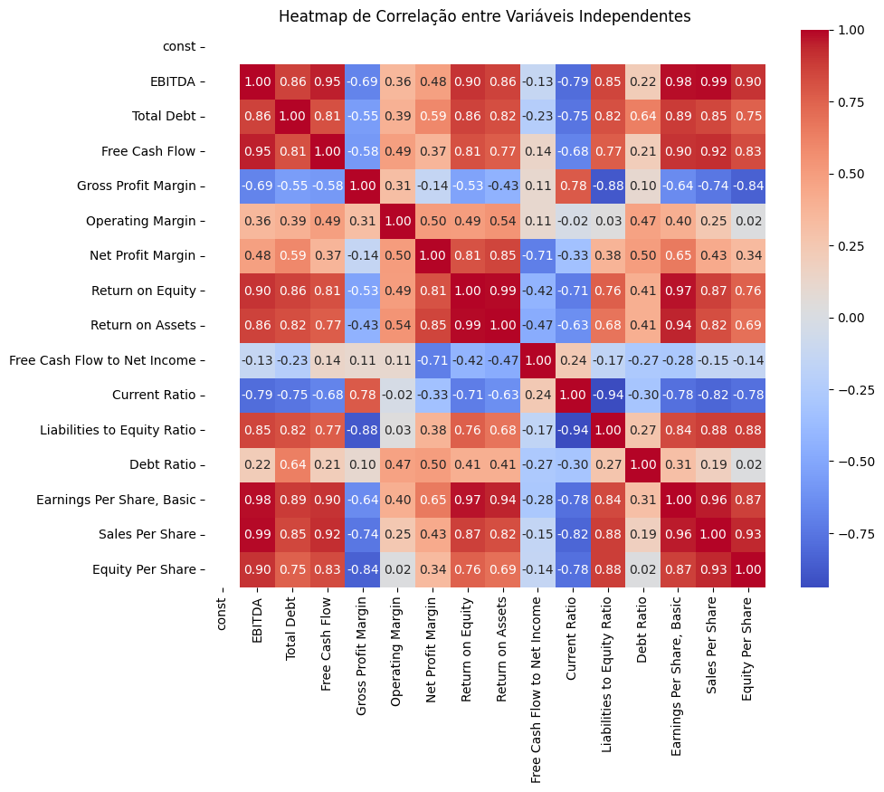

```python
# Calcular a matriz de correlação
correlacao = X_df.corr()

# Criar o heatmap de correlação
plt.figure(figsize=(10, 8))
sns.heatmap(correlacao, annot=True, cmap='coolwarm', fmt=".2f")
plt.title('Heatmap de Correlação entre Variáveis Independentes')
plt.show()
```

Foi identificado variáveis com altíssima correlação entre umas e as outras. Para resolver isso geraremos um novo modelo.

### 3.2. Modelo Linear Corrigido

#### Como foi visto no item anterior, tivemos problemas de Multicolinearidade do modelo inicial, para resolver esse problema faremos a abordagem de se retirar algumas variáveis independentes baseado nos seus p-valores e correlações e então gerar um novo modelo. Nesse passo o autor foi retirando uma variável de cada vez que parecia pertinente a ser removida, até gerar um modelo apenas com variáveis independentes significativas e que gerassem um modelo aceitável. O resultado final pode ser encontrado a seguir.

```python
del X_df['Sales Per Share']
del X_df['Earnings Per Share, Basic']
del X_df['Return on Assets']
del X_df['Free Cash Flow']
del X_df['Liabilities to Equity Ratio']
del X_df['Gross Profit Margin']
del X_df['EBITDA']
del X_df['Return on Equity']

del X_df['Debt Ratio']
del X_df['Total Debt']
del X_df['Operating Margin']
```

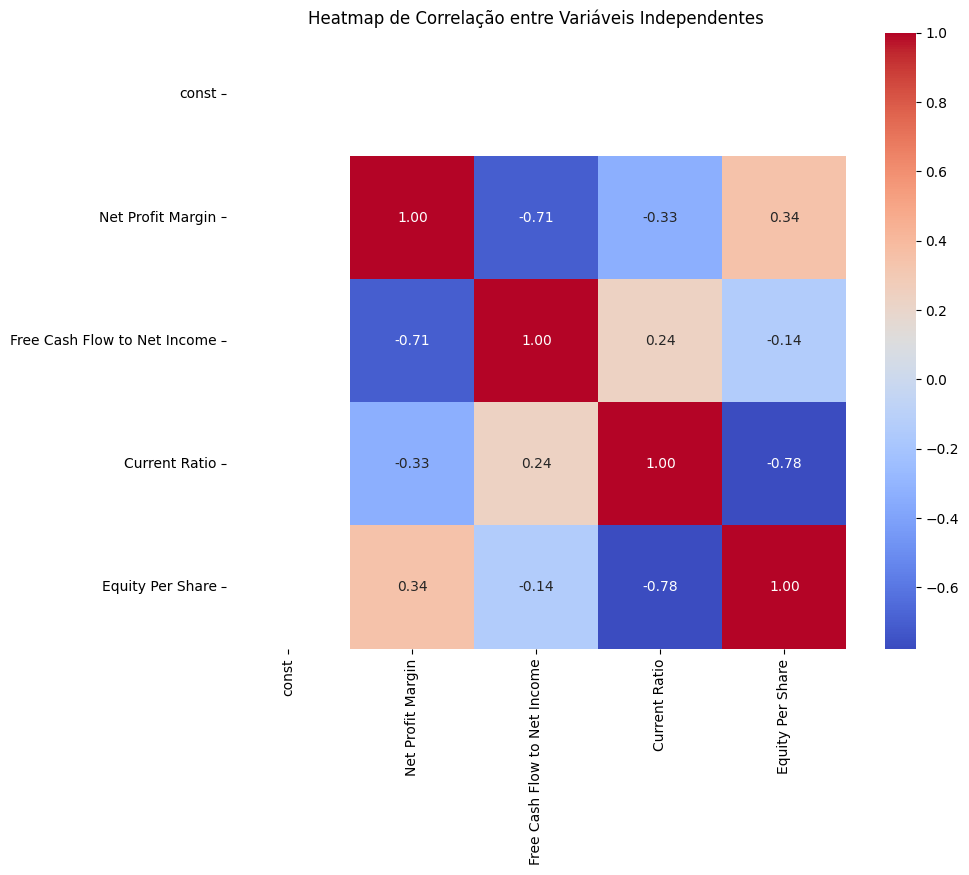

```python
# Calcular a matriz de correlação
correlacao = X_df.corr()

# Criar o heatmap de correlação
plt.figure(figsize=(10, 8))
sns.heatmap(correlacao, annot=True, cmap='coolwarm', fmt=".2f")
plt.title('Heatmap de Correlação entre Variáveis Independentes')
plt.show()
```

```python
# Criando o modelo de regressão linear
modelo = sm.OLS(Y_df, X_df).fit()

# Exibindo um resumo da análise de regressão
print(modelo.summary())
```

```
                            OLS Regression Results
==============================================================================
Dep. Variable:             Adj. Close   R-squared:                       0.965
Model:                            OLS   Adj. R-squared:                  0.961
Method:                 Least Squares   F-statistic:                     233.3
Date:                Tue, 07 Nov 2023   Prob (F-statistic):           3.32e-24
Time:                        19:15:28   Log-Likelihood:                -130.37
No. Observations:                  39   AIC:                             270.7
Df Residuals:                      34   BIC:                             279.1
Df Model:                           4
Covariance Type:            nonrobust
================================================================================================
                                   coef    std err          t      P>|t|      [0.025      0.975]
------------------------------------------------------------------------------------------------
const                         -123.7452     15.794     -7.835      0.000    -155.842     -91.649
Net Profit Margin              504.4347     46.545     10.838      0.000     409.844     599.025
Free Cash Flow to Net Income    23.4625      2.922      8.030      0.000      17.524      29.401
Current Ratio                   -5.0801      1.538     -3.303      0.002      -8.206      -1.954
Equity Per Share                 5.8961      0.478     12.328      0.000       4.924       6.868
==============================================================================
Omnibus:                       20.446   Durbin-Watson:                   1.723
Prob(Omnibus):                  0.000   Jarque-Bera (JB):               38.183
Skew:                          -1.308   Prob(JB):                     5.11e-09
Kurtosis:                       7.082   Cond. No.                         569.
==============================================================================

Notes:
[1] Standard Errors assume that the covariance matrix of the errors is correctly specified.
```

#### Modelo Final:

#### Adj. Close = -123.7452 + 504.4347 * (Net Profit Margin) + 23.4625 * (Free Cash Flow to Net Income) - 5.0801 * (Current Ratio) + 5.8961 * (Equity Per Share)

## 4. Avaliação do Modelo

### 4.1. Testes de Heterocedasticidade

##### Com o modelo gerado foi plotado o gráfico de Dispersão dos Resíduos a fim de se verificar comportamentos de heterocedasticidade.

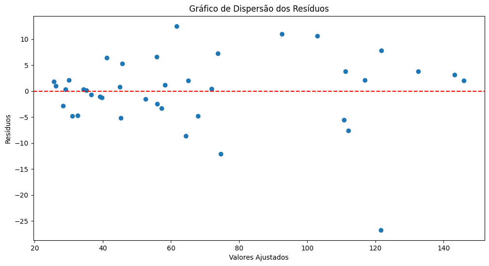

```python
plt.figure(figsize=(12, 6))
plt.scatter(modelo.fittedvalues, modelo.resid)
plt.axhline(y=0, color="r", linestyle="--")
plt.xlabel("Valores Ajustados")
plt.ylabel("Resíduos")
plt.title("Gráfico de Dispersão dos Resíduos")
```

#### Visualmente nada indica uma heterocedasticidade. Faremos o teste de Breusch-Pagan a fim de se confirmar numericamente.

```python
bp_test = het_breuschpagan(modelo.resid, X_df)
print(f"p-valor: {bp_test[1]}")
```

```
p-valor: 0.19509221694685552
```

Como o p-valor é de 0,195 (acima de 0,05), não há evidência estatística para rejeitar a hipótese nula. Portanto, com base no teste Breusch-Pagan, não há indicação de heterocedasticidade nos resíduos do modelo. Isso significa que a variância dos erros é considerada constante e a suposição de homocedasticidade é atendida.

### 4.2. Testes de Multicolinearidade

#### Teste de Variance Inflation Factor (VIF) para verificar a presença de multicolinearidade.

```python
vif = pd.DataFrame()
vif["Variável"] = X_df.columns
vif["VIF"] = [variance_inflation_factor(X_df.values, i) for i in range(X_df.shape[1])]
print(f"Teste VIF (Multicolinearidade):\n{vif}")
```

```
Teste VIF (Multicolinearidade):
                       Variável         VIF
0                         const  180.904011
1             Net Profit Margin    2.277379
2  Free Cash Flow to Net Income    2.111765
3                 Current Ratio    2.634342
4              Equity Per Share    2.711322
```

Todos os VIFs das variáveis independentes deram menor que 5, logo podemos descartar a hipótese de que existe multicolinearidade entre as variáveis.

### 4.3. Testes de Autocorrelação dos Resíduos

```python
durbin_watson_stat = durbin_watson(modelo.resid)
print("Teste de Durbin-Watson:", durbin_watson_stat)
```

```
Teste de Durbin-Watson: 1.7233191900594604
```

O valor 1.7233 está entre 1,5 e 2,5 indicando ausência de autocorrelação positiva ou negativa.

### 4.4. Erro Quadrático e Absoluto

```python
predicted_values = modelo.predict()
mse = np.mean((Y_df - predicted_values) ** 2)
print("Erro Médio Quadrático (MSE):", mse)
```

```
Erro Médio Quadrático (MSE): 46.88068360918349
```

```python
mae = np.mean(np.abs(Y_df - predicted_values))
print("Erro Médio Absoluto (MAE):", mae)
```

```
Erro Médio Absoluto (MAE): 4.763354886474204
```

### 4.5. Coeficiente de Determinação

```python
r2 = modelo.rsquared
print("Coeficiente de Determinação (R2):", r2)
```

```
Coeficiente de Determinação (R2): 0.9648539130668836
```

# Resultados

#### Ao utilizar o modelo final podemos plotar o gráfico abaixo, dos valores reais e do valor ajustado.

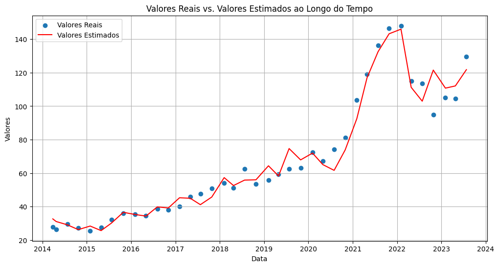

```python
# Variáveis independentes originais
dates = df['Date']

# Prever os valores com base no modelo ajustado
predicted_values = modelo.predict()

# Criar um gráfico de dispersão dos valores reais vs. valores estimados em relação à data
plt.figure(figsize=(12, 6))
plt.scatter(dates, Y_df, label="Valores Reais")
plt.plot(dates, predicted_values, label="Valores Estimados", color='red')
plt.xlabel("Data")
plt.ylabel("Valores")
plt.title("Valores Reais vs. Valores Estimados ao Longo do Tempo")
plt.grid(True)
plt.legend()
plt.show()
```

#### Também foi montada a tabela com a data de referência, o valor real, o valor previsto e o erro absoluto e erro percentual.

```python
predicted_values = modelo.predict()

# Calcular os erros
errors = Y_df - predicted_values
percentage_error = (abs(errors) / Y_df) * 100

# Criar um DataFrame com as informações
results_df = pd.DataFrame({'Data': dates, 'Valor Real': Y_df, 'Valor Previsto': predicted_values, 'Erro': errors, 'Erro Percentual (%)': percentage_error})

results_df
```

|  | Data | Valor Real | Valor Previsto | Erro | Erro Percentual (%) |
| --- | --- | --- | --- | --- | --- |
| 0 | 2014-03-27 | 27.92 | 32.614481 | -4.694481 | 16.814044 |
| 1 | 2014-04-24 | 26.26 | 31.035903 | -4.775903 | 18.186987 |
| 2 | 2014-07-25 | 29.45 | 29.072381 | 0.377619 | 1.282237 |
| 3 | 2014-10-23 | 27.20 | 26.202476 | 0.997524 | 3.667368 |
| 4 | 2015-01-29 | 25.53 | 28.331494 | -2.801494 | 10.973341 |
| 5 | 2015-04-29 | 27.45 | 25.608720 | 1.841280 | 6.707759 |
| 6 | 2015-07-23 | 32.21 | 30.095690 | 2.114310 | 6.564142 |
| 7 | 2015-10-29 | 35.85 | 36.541352 | -0.691352 | 1.928457 |
| 8 | 2016-02-04 | 35.40 | 35.237659 | 0.162341 | 0.458591 |
| 9 | 2016-05-03 | 34.62 | 34.285025 | 0.334975 | 0.967576 |
| 10 | 2016-08-04 | 38.58 | 39.784292 | -1.204292 | 3.121545 |
| 11 | 2016-11-03 | 38.11 | 39.157236 | -1.047236 | 2.747928 |
| 12 | 2017-02-03 | 40.07 | 45.237429 | -5.167429 | 12.896004 |
| 13 | 2017-05-02 | 45.82 | 44.957988 | 0.862012 | 1.881301 |
| 14 | 2017-07-25 | 47.53 | 41.115264 | 6.414736 | 13.496184 |
| 15 | 2017-10-27 | 50.96 | 45.681081 | 5.278919 | 10.358947 |
| 16 | 2018-02-06 | 54.03 | 57.281073 | -3.251073 | 6.017163 |
| 17 | 2018-04-24 | 51.00 | 52.533529 | -1.533529 | 3.006920 |
| 18 | 2018-07-24 | 62.40 | 55.800816 | 6.599184 | 10.575615 |
| 19 | 2018-10-26 | 53.57 | 55.980739 | -2.410739 | 4.500166 |
| 20 | 2019-02-06 | 55.76 | 64.339173 | -8.579173 | 15.385891 |
| 21 | 2019-04-30 | 59.42 | 58.250540 | 1.169460 | 1.968126 |
| 22 | 2019-07-26 | 62.52 | 74.631970 | -12.111970 | 19.372952 |
| 23 | 2019-10-29 | 63.13 | 67.876449 | -4.746449 | 7.518532 |
| 24 | 2020-02-04 | 72.35 | 71.931966 | 0.418034 | 0.577794 |
| 25 | 2020-04-29 | 67.07 | 65.053427 | 2.016573 | 3.006670 |
| 26 | 2020-07-31 | 74.15 | 61.613892 | 12.536108 | 16.906417 |
| 27 | 2020-10-30 | 81.05 | 73.812037 | 7.237963 | 8.930244 |
| 28 | 2021-02-03 | 103.50 | 92.501696 | 10.998304 | 10.626381 |
| 29 | 2021-04-28 | 119.00 | 116.877467 | 2.122533 | 1.783641 |
| 30 | 2021-07-28 | 136.38 | 132.517941 | 3.862059 | 2.831837 |
| 31 | 2021-10-27 | 146.43 | 143.226064 | 3.203936 | 2.188032 |
| 32 | 2022-02-02 | 148.04 | 145.993449 | 2.046551 | 1.382431 |
| 33 | 2022-04-27 | 115.02 | 111.231504 | 3.788496 | 3.293771 |
| 34 | 2022-07-27 | 113.60 | 102.959688 | 10.640312 | 9.366472 |
| 35 | 2022-10-26 | 94.82 | 121.538066 | -26.718066 | 28.177670 |
| 36 | 2023-02-03 | 105.22 | 110.747715 | -5.527715 | 5.253483 |
| 37 | 2023-04-26 | 104.45 | 112.074520 | -7.624520 | 7.299684 |
| 38 | 2023-07-26 | 129.66 | 121.797809 | 7.862191 | 6.063698 |

```python
max_percentage_error = percentage_error.max()
mean_percentage_error = percentage_error.mean()
print(f"Maior Erro Percentual: {max_percentage_error:.2f}%")
print(f"Média do Erro Percentual: {mean_percentage_error:.2f}%")
```

```
Maior Erro Percentual: 28.18%
Média do Erro Percentual: 7.39%
```

Tivemos um caso em que o erro percentual foi bastante elevado, 28%, porém a sua média fica por volta de 7%. Acredito que dependendo da função a ser empregada, de apenas verificar uma tendência e não prever com tanta precisão, esse erro está aceitável. Vai variar do objetivo do stakeholder.

# Modelo de Regressão Linear

#### O modelo final gerado foi o seguinte:

#### Adj. Close = -123.7452 + 504.4347 * (Net Profit Margin) + 23.4625 * (Free Cash Flow to Net Income) - 5.0801 * (Current Ratio) + 5.8961 * (Equity Per Share)

```python
print(modelo.summary())
```

```
                            OLS Regression Results
==============================================================================
Dep. Variable:             Adj. Close   R-squared:                       0.965
Model:                            OLS   Adj. R-squared:                  0.961
Method:                 Least Squares   F-statistic:                     233.3
Date:                Tue, 07 Nov 2023   Prob (F-statistic):           3.32e-24
Time:                        19:15:29   Log-Likelihood:                -130.37
No. Observations:                  39   AIC:                             270.7
Df Residuals:                      34   BIC:                             279.1
Df Model:                           4
Covariance Type:            nonrobust
================================================================================================
                                   coef    std err          t      P>|t|      [0.025      0.975]
------------------------------------------------------------------------------------------------
const                         -123.7452     15.794     -7.835      0.000    -155.842     -91.649
Net Profit Margin              504.4347     46.545     10.838      0.000     409.844     599.025
Free Cash Flow to Net Income    23.4625      2.922      8.030      0.000      17.524      29.401
Current Ratio                   -5.0801      1.538     -3.303      0.002      -8.206      -1.954
Equity Per Share                 5.8961      0.478     12.328      0.000       4.924       6.868
==============================================================================
Omnibus:                       20.446   Durbin-Watson:                   1.723
Prob(Omnibus):                  0.000   Jarque-Bera (JB):               38.183
Skew:                          -1.308   Prob(JB):                     5.11e-09
Kurtosis:                       7.082   Cond. No.                         569.
==============================================================================

Notes:
[1] Standard Errors assume that the covariance matrix of the errors is correctly specified.
```

# Discussão

Tivemos um modelo que conseguiu se ajustar com boa margem a maioria dos eventos como podemos observar no gráfico gerado anteriormente. Porém tivemos problemas em alguns casos pricipalmente em 2022-10-26. Se nos atentarmos aos eventos por volta dessa data, tivemos o início da pandemia de covid-19 em 2020, por causa da natureza de negócio do Google, a demanda por seus serviços explodiu devido ao isolamento social e a difusão do home office. Tivemos o preço de fechamento de suas ações (nossa variável dependente) mais que dobrando de valor em 2 anos, e então uma queda significativa passando 2022, justamente o nosso ponto de maior erro, 2022-10-26. Vale ressaltar que essa queda abrupta nessa época ocorre em quase todas as empresas de tecnologia, por uma bolha que surgiu na área, em que muitas empresas investiram demais em crescimento, infraestrutura e pessoal. Porém com o fim da pandemia a demanda não conseguiu continuar pagando os custos em grande parte das empresas.

Por se tratar de um evento quase extraordinário que é uma pandemia seguido por uma bolha estourando, até que o modelo conseguiu se adaptar com uma certa facilidade na maioria dos casos com as variáveis disponíveis.

# Conclusão

Este estudo de regressão linear fornece uma análise detalhada das relações entre o preço de fechamento de ações da Google e seus indicadores financeiros. Com base nos resultados, concluímos que Margem de lucro líquido, Relação entre fluxo de caixa livre e Lucro líquido, Patrimônio líquido por ação, são indicadores importantes e positivos para um fechamento de preço das ações.

- Recomendações

Conforme observado, inicialmente tinhamos um total de 15 indicadores (variáveis independentes), porém só utilizamos 4 no nosso modelo final. Isso se dá porque a natureza de alguns indicadores são bem relacionadas. A recomendação é que se procure alguém com conhecimento do domínio para ajudar na exclusão de alguns indicadores secundários, pois o autor não tem esse conhecimento, e só seguiu com a exclusão utilizando a análise numérica.

- Limitações

Conforme comentado no item Discussão, tivemos um erro maior na previsão no cenário de estouro da bolha de tecnlogia. Isso pode estar ocorrendo porque as medidas disponíveis para a análise são restritamente financeiras. Trazer mais medidas de natureza diferente para tentar explicar um cenário de pandemia e então estouro de bolha pode ajudar na precisão e eficácia do modelo.

- Próximos Passos

Para estudos futuros seria válido trazer mais variáveis como comentado no item anterior, assim como utilizar a consultoria de alguém com conhecimento do domínio.